# C1X Data Challenge

Manikandan .R

November 23, 2016

## Data

500k User section collection- consists of ~20M web queries collected from ~650k users over three months.

```r
setwd("C:\\intro_to_datascience\\competitions\\c1x")
df<- read.csv("user-ct-test-collection-02.txt", header= TRUE, sep='\t')
str(df)
```

```
## 'data.frame':    3537372 obs. of  5 variables:
##  $ AnonID   : int  479 479 479 479 479 479 479 479 479 479 ...
##  $ Query    : Factor w/ 1219923 levels "'","''","''''''''''",..: 319265 46899 319284 941157 941157 159737 159737 159737 160378 160379 ...
##  $ QueryTime: Factor w/ 2247762 levels "2006-03-01 00:01:16",..: 13668 40439 81876 82022 82022 82996 82996 82996 83100 83183 ...
##  $ ItemRank : int  NA NA 1 1 2 4 1 5 9 3 ...
##  $ ClickURL : Factor w/ 384917 levels "","ftp://dftp.maritimemagazine.com/mn200502o2.pdf",..: 1 1 171859 46123 210428 150789 253249 367070 146623 331564 ...
```

## Data Pre processing

We split the data into 2 sets-

[output not shown]

```r
df1<- subset(df,ItemRank!= 'NA')
df[df=='NA']<- NA
df2<- subset(df,is.na(df$ItemRank))
str(df1)
```

```
## 'data.frame':    1902838 obs. of  5 variables:
##  $ AnonID   : int  479 479 479 479 479 479 479 479 479 479 ...
##  $ Query    : Factor w/ 1219923 levels "'","''","''''''''''",..: 319284 941157 941157 159737 159737 159737 160378 160379 129184 129192 ...
##  $ QueryTime: Factor w/ 2247762 levels "2006-03-01 00:01:16",..: 81876 82022 82022 82996 82996 82996 83100 83183 83261 83299 ...
##  $ ItemRank : int  1 1 2 4 1 5 9 3 1 1 ...
##  $ ClickURL : Factor w/ 384917 levels "","ftp://dftp.maritimemagazine.com/mn200502o2.pdf",..: 171859 46123 210428 150789 253249 367070 146623 331564 113929 63921 ...
```

```r
str(df2)
```

```
## 'data.frame':    1634534 obs. of  5 variables:
##  $ AnonID   : int  479 479 479 479 479 479 479 479 479 479 ...
##  $ Query    : Factor w/ 1219923 levels "'","''","''''''''''",..: 319265 46899 160248 159610 132650 186080 186084 447309 695020 1034559 ...
##  $ QueryTime: Factor w/ 2247762 levels "2006-03-01 00:01:16",..: 13668 40439 83231 83245 83257 109827 109832 201284 234078 360616 ...
##  $ ItemRank : int  NA NA NA NA NA NA NA NA NA NA ...
##  $ ClickURL : Factor w/ 384917 levels "","ftp://dftp.maritimemagazine.com/mn200502o2.pdf",..: 1 1 1 1 1 1 1 1 1 1 ...
```

Removing duplicate entries

```r
df1<- unique(df1)
df2<- unique(df2)
nrow(df1)
```

```
## [1] 1754149
```

```r
nrow(df2)
```

```
## [1] 1623197
```

## Exploring ItemRank variable

```r
ranktab<-round(prop.table(table(df1$ItemRank))*100)
ranktabdf<- as.data.frame(ranktab)
str(ranktabdf)
```

```
## 'data.frame':    497 obs. of  2 variables:
##  $ Var1: Factor w/ 497 levels "0","1","2","3",..: 1 2 3 4 5 6 7 8 9 10 ...
##  $ Freq: num  0 41 12 9 6 5 4 3 3 3 ...
```

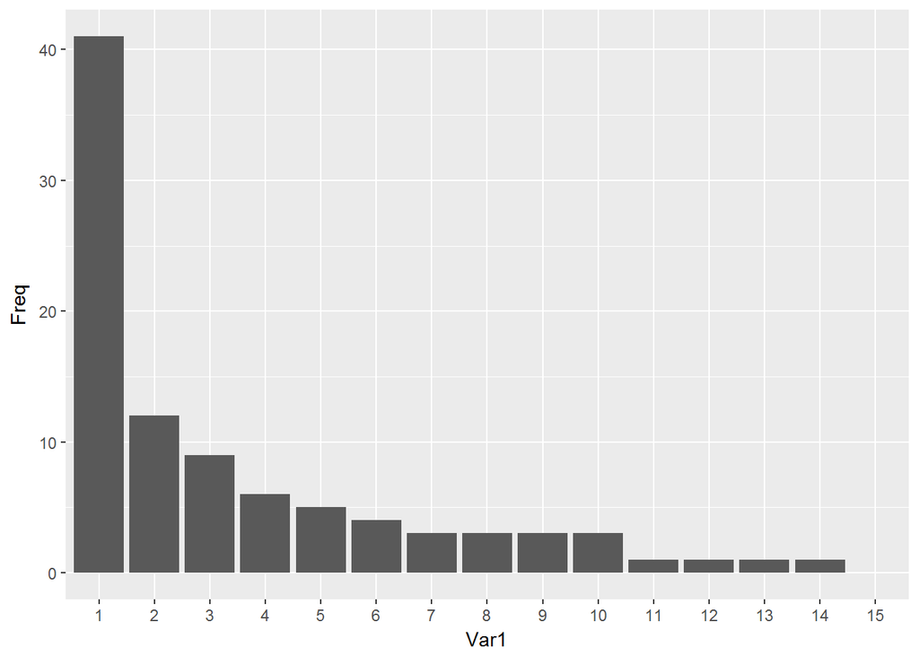

```r
ranktabdf1<- ranktabdf[2:16,]
library(ggplot2)
ggplot(ranktabdf1,aes(x= Var1,y= Freq))+geom_bar(stat = "identity")
```

> It is infered that 89% of clicked users were able to get their searches within 10 ranked items

## Exploring Queries searched by user

```r
library(data.table)
library(plyr)
library(dplyr)
dtbl<- tbl_df(df)
dtbl3<- dtbl %>% group_by(AnonID) %>% summarise(n=n_distinct(Query))
head(dtbl3,10)
```

```
## # A tibble: 10 × 2
##    AnonID     n
##     <int> <int>
## 1     479    77
## 2     507    26
## 3     946     2
## 4    1020    66
## 5    1021    51
## 6    1521    20
## 7    2015    11
## 8    2708   305
## 9    2729    57
## 10   2914    12
```

```r
val<- dtbl3[,2]
querytab<- round(prop.table(table(val))*100)
querytab<- as.data.frame(querytab)
querytab1<- querytab[1:50,]
querytbl<- tbl_df(querytab1)
mutate(querytbl,cumulative=cumsum(querytbl$Freq))
```

```
## # A tibble: 50 × 3
##       val  Freq cumulative
##    <fctr> <dbl>      <dbl>
## 1       1    11         11
## 2       2     7         18
## 3       3     6         24
## 4       4     5         29
## 5       5     4         33
## 6       6     4         37
## 7       7     3         40
## 8       8     3         43
## 9       9     3         46
## 10     10     3         49
## # ... with 40 more rows
```

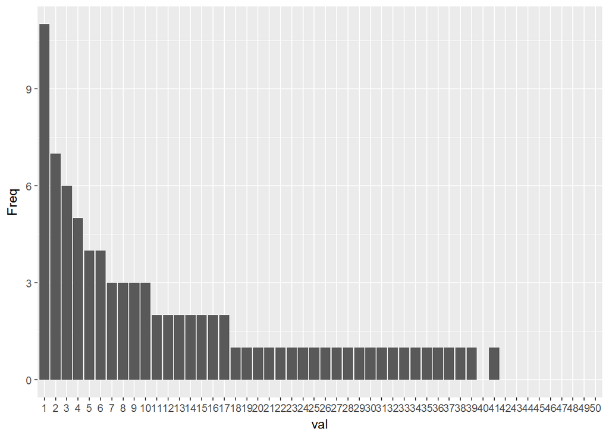

```r
ggplot(querytab1,aes(x=val,y=Freq))+geom_bar(stat = "identity")
```

> Nearly 50% of the users queried the search engine with 1-10 query topics

## Exploring at Overall search engine level

We separate the users into 2 segments-

users who got relevant search- those who had atleast clicked on one query search result. users who didn’t get relevant search- those who hasn’t clicked on any query search result.

Reshping the data to get click details at user level Deriving metrics at an overall search engine level- Overall Click Rate and Overall Non-Click Rate.

```r
library("magrittr")
dbtl4<- dtbl %>% select(AnonID,ItemRank)
dbtl4$rank<-dbtl4$ItemRank
dbtl4[dbtl4=='NA']<- NA

dbtl4$rank<- apply(dbtl4[,c("ItemRank")],1, function(i) ifelse((is.na(i)),'NA','CL'))
head(dbtl4)
```

```
## # A tibble: 6 × 3
##   AnonID ItemRank  rank
##    <int>    <int> <chr>
## 1    479       NA    NA
## 2    479       NA    NA
## 3    479        1    CL
## 4    479        1    CL
## 5    479        2    CL
## 6    479        4    CL
```

```r
dbtl6<- dbtl4 %>% group_by(AnonID,rank) %>% summarise(n=n())
head(dbtl6)
```

```
## Source: local data frame [6 x 3]
## Groups: AnonID [4]
##
##   AnonID  rank     n
##    <int> <chr> <int>
## 1    479    CL    88
## 2    479    NA    35
## 3    507    CL    63
## 4    507    NA    52
## 5    946    NA     2
## 6   1020    CL    64
```

```r
library(tidyr)
dbtl7<- spread(dbtl6,rank,n)
head(dbtl7)
```

```
## Source: local data frame [6 x 3]
## Groups: AnonID [6]
##
##   AnonID    CL  `NA`
##    <int> <int> <int>
## 1    479    88    35
## 2    507    63    52
## 3    946    NA     2
## 4   1020    64    44
## 5   1021    35    48
## 6   1521    NA    27
```

```r
nrow(dbtl7)
```

```
## [1] 61592
```

```r
dbtl9<- dbtl7[which(!is.na(dbtl7$CL)),]
nrow(dbtl9)
```

```
## [1] 49294
```

```r
dbtl8<- dbtl7[which(is.na(dbtl7$CL)),]
nrow(dbtl8)
```

```
## [1] 12298
```

```r
OverallCR<- nrow(dbtl9)/nrow(dbtl7)*100
OverallNCR<- nrow(dbtl8)/nrow(dbtl7)*100
OverallCR
```

```
## [1] 80.03312
```

```r
OverallNCR
```

```
## [1] 19.96688
```

## Exploring the users of relevant search

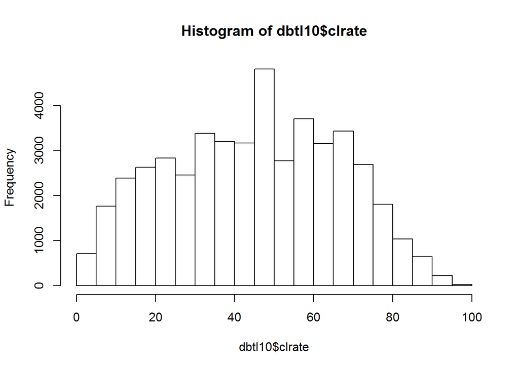

```r
a<- data.frame(name=c("ID","Click","NoClick"))
colnames(dbtl9)<- a$name
dbtl10<- dbtl9 %>% mutate(Total = Click+NoClick) %>% mutate(clrate= round((Click/Total)*100)) %>% mutate(nonclrate= round((NoClick/Total)*100))

hist(dbtl10$clrate)
```

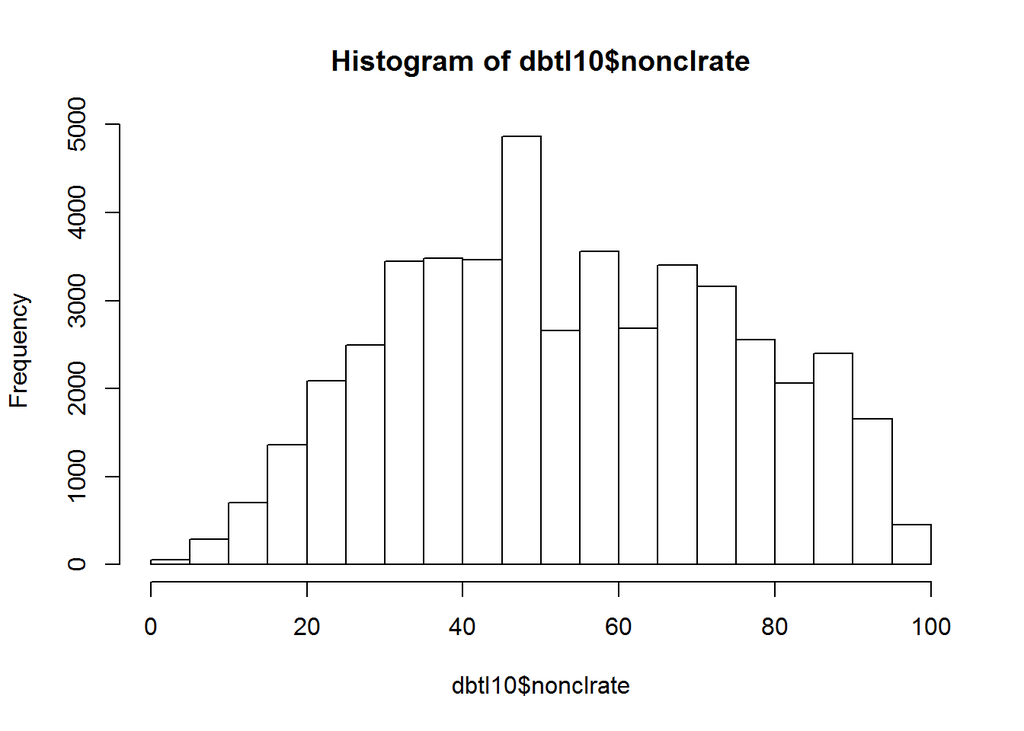

```r
hist(dbtl10$nonclrate)
```

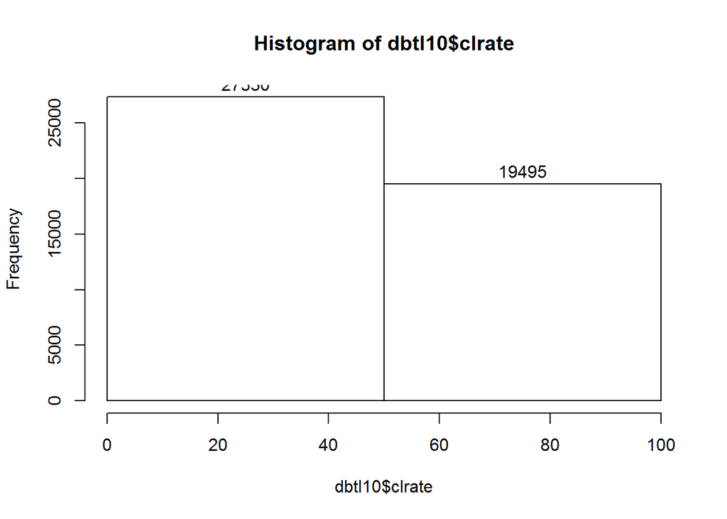

```r
hist(dbtl10$clrate,breaks = 2,labels = TRUE)
```

```r
mean(dbtl10$clrate,na.rm = TRUE)
```

```
## [1] 45.5755
```

```r
mean(dbtl10$nonclrate,na.rm = TRUE)
```

```
## [1] 54.42381
```

> 58% of the users have their click rate <= 50.

## Exploring the users who had not got relevant search

Here, we consider all those users who haven’t clicked on any search results.

```r
dbtl8<- as.data.frame(dbtl8)
a<- data.frame(name=c("ID","Click","NoClick"))
colnames(dbtl8)<- a$name
head(dbtl8)
```

```
##      ID Click NoClick
## 1   946    NA       2
## 2  1521    NA      27
## 3  4349    NA      10
## 4  6860    NA       6
## 5 16312    NA       2
## 6 27095    NA      36
```

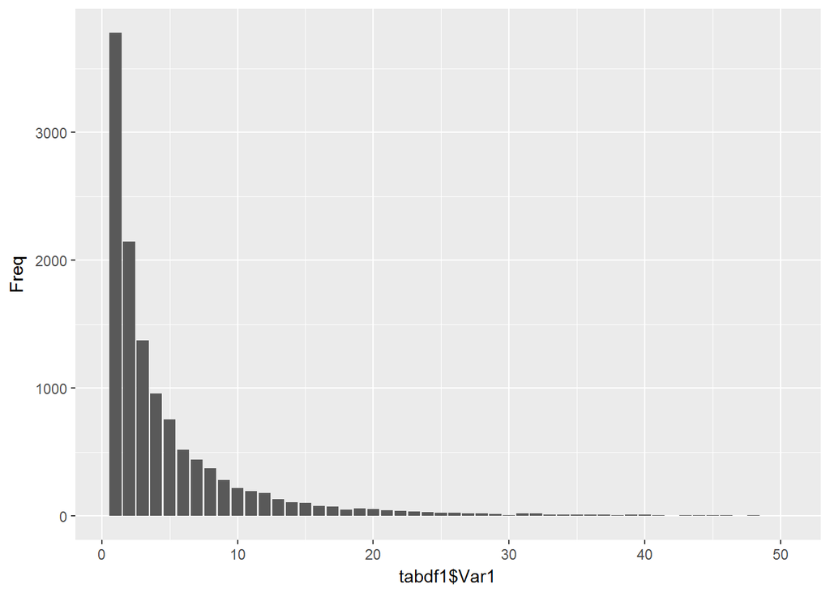

```r
tabdf<- table(dbtl8$NoClick)
tabdf<- as.data.frame(tabdf)
tabdf$Var1<- as.numeric(tabdf$Var1)
tabdf1<- tabdf[which(tabdf$Var1<=50),]
ggplot(tabdf1,aes(x=tabdf1$Var1,y=Freq))+geom_bar(stat = "identity")
```

> 30% of users stop their search with one query(less business action could be taken on this segment). 57% of users do not click any search results for their query topics ranging from 2 to 10.(this segment calls for business attention)

## top urls showing up in the results

```r
dtb1<- tbl_df(df1)
dtb2<- count(dtb1,ClickURL)
head(dtb2)
```

```
## # A tibble: 6 × 2
##                                         ClickURL     n
##                                           <fctr> <int>
## 1 ftp://dftp.maritimemagazine.com/mn200502o2.pdf     1
## 2               http:\017\017www.hotmail.com\017     1
## 3                                        http://     2
## 4                  http://-vraiment.blogspot.com     1
## 5                      http:// adulted.about.com     1
## 6                        http:// crime.about.com     1
```

```r
dtb2<- arrange(dtb2,desc(n))
head(dtb2,10)
```

```
## # A tibble: 10 × 2
##                        ClickURL     n
##                          <fctr> <int>
## 1         http://www.google.com 25794
## 2        http://www.myspace.com 13304
## 3          http://www.yahoo.com 12118
## 4       http://en.wikipedia.org 11522
## 5         http://www.amazon.com 10345
## 6           http://www.imdb.com  9227
## 7       http://www.mapquest.com  8414
## 8           http://www.ebay.com  6035
## 9         http://mail.yahoo.com  4002
## 10 http://www.bankofamerica.com  3832
```

## Time spent by users in search engine.

The objective is to capture the time spent per day calculated to be one session. if the user had spent only on one query, time spent would be zero. if a user had spend 5 query topics in a day, then the time spent is calculated between the time of first query and last query of the day.

```r
df4<- df
dbtt3<- tbl_df(df4)
str(dbtt3)
```

```
## Classes 'tbl_df', 'tbl' and 'data.frame':    3537372 obs. of  5 variables:
##  $ AnonID   : int  479 479 479 479 479 479 479 479 479 479 ...
##  $ Query    : Factor w/ 1219923 levels "'","''","''''''''''",..: 319265 46899 319284 941157 941157 159737 159737 159737 160378 160379 ...
##  $ QueryTime: Factor w/ 2247762 levels "2006-03-01 00:01:16",..: 13668 40439 81876 82022 82022 82996 82996 82996 83100 83183 ...
##  $ ItemRank : int  NA NA 1 1 2 4 1 5 9 3 ...
##  $ ClickURL : Factor w/ 384917 levels "","ftp://dftp.maritimemagazine.com/mn200502o2.pdf",..: 1 1 171859 46123 210428 150789 253249 367070 146623 331564 ...
```

```r
dbtt3$Date<- as.Date(dbtt3$QueryTime)
dbtt3$Time<- format(as.POSIXct(dbtt3$QueryTime),format = "%H:%M:%S")

dbtt3 %>% group_by(AnonID,Date) %>% summarise(min(Time),max(Time))->dbtt4
head(dbtt4)
```

```
## Source: local data frame [6 x 4]
## Groups: AnonID [1]
##
##   AnonID       Date `min(Time)` `max(Time)`
##    <int>     <date>       <chr>       <chr>
## 1    479 2006-03-01    16:01:20    16:01:20
## 2    479 2006-03-02    14:48:55    14:48:55
## 3    479 2006-03-03    22:37:46    23:31:48
## 4    479 2006-03-04    22:11:31    23:05:53
## 5    479 2006-03-06    21:57:14    22:57:22
## 6    479 2006-03-08    00:14:55    17:23:07
```

```r
str(dbtt4)
```

```
## Classes 'grouped_df', 'tbl_df', 'tbl' and 'data.frame':  719461 obs. of  4 variables:
##  $ AnonID   : int  479 479 479 479 479 479 479 479 479 479 ...
##  $ Date     : Date, format: "2006-03-01" "2006-03-02" ...
##  $ min(Time): chr  "16:01:20" "14:48:55" "22:37:46" "22:11:31" ...
##  $ max(Time): chr  "16:01:20" "14:48:55" "23:31:48" "23:05:53" ...
##  - attr(*, "vars")=List of 1
##   ..$ : symbol AnonID
##  - attr(*, "drop")= logi TRUE
```

```r
library("chron")

dbtt4$MINTime<- chron(times=dbtt4$`min(Time)`)
dbtt4$MAXTime<- chron(times=dbtt4$`max(Time)`)
dbtt4$timespent<- dbtt4$MAXTime-dbtt4$MINTime
head(dbtt4)
```

```
## Source: local data frame [6 x 7]
## Groups: AnonID [1]
##
##   AnonID       Date `min(Time)` `max(Time)`     MINTime     MAXTime
##    <int>     <date>       <chr>       <chr> <S3: times> <S3: times>
## 1    479 2006-03-01    16:01:20    16:01:20    16:01:20    16:01:20
## 2    479 2006-03-02    14:48:55    14:48:55    14:48:55    14:48:55
## 3    479 2006-03-03    22:37:46    23:31:48    22:37:46    23:31:48
## 4    479 2006-03-04    22:11:31    23:05:53    22:11:31    23:05:53
## 5    479 2006-03-06    21:57:14    22:57:22    21:57:14    22:57:22
## 6    479 2006-03-08    00:14:55    17:23:07    00:14:55    17:23:07
## # ... with 1 more variables: timespent <S3: times>
```

```r
dim(dbtt4)
```

```
## [1] 719461      7
```

```r
dbtt4$minutesspent<- 60*24* as.numeric(times(dbtt4$timespent))
head(dbtt4)
```

```
## Source: local data frame [6 x 8]
## Groups: AnonID [1]
##
##   AnonID       Date `min(Time)` `max(Time)`     MINTime     MAXTime
##    <int>     <date>       <chr>       <chr> <S3: times> <S3: times>
## 1    479 2006-03-01    16:01:20    16:01:20    16:01:20    16:01:20
## 2    479 2006-03-02    14:48:55    14:48:55    14:48:55    14:48:55
## 3    479 2006-03-03    22:37:46    23:31:48    22:37:46    23:31:48
## 4    479 2006-03-04    22:11:31    23:05:53    22:11:31    23:05:53
## 5    479 2006-03-06    21:57:14    22:57:22    21:57:14    22:57:22
## 6    479 2006-03-08    00:14:55    17:23:07    00:14:55    17:23:07
## # ... with 2 more variables: timespent <S3: times>, minutesspent <dbl>
```

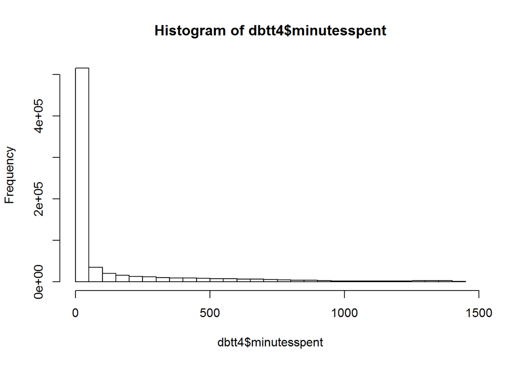

```r
dbtt4$minutesspent<- round(dbtt4$minutesspent,0)
hist(dbtt4$minutesspent)
```

The distribution appears to be right skewed.

## Insights to the Product manager of Search

*The Search display page should show 14 results per page. This covers 93% click probability of relevant users and hence, higher click rates* *Eventhough overall click rate figures are better, click rate per user needs attention*